# If statements dans Excel et R

## Prochains EEG séminars

Création d'un journal club destiner à affiner les connaissance de chacun dans le domaine de :

- l'EEG
- IRMf et autres méthodes d'imagerie cérébrale
- Statistiques et méthodologie
- aspects techniques (utilisation d'un nouveau logiciel,…)
- Autre

## Prochains EEG séminars

Fonctionnement :

- Pour le premier séminaire, article choisi par Marina
- Présentation d'Anne-lise et/ou Eric
- A la fin de la présentation –> présentateurs proposent un article pour le prochain journal club
- Attribution de la présentation de l'article choisi à quelqu'un parmi l'audience
- La personne désignée présentera l'article et choisira un autre article attribué au suivant
- Ainsi de suite…

Fonctionnement structuré mais flexible…

## Objectifs

- Poser les principes de la manipulation de base de données
- Intérêts des si/if et autres statements
- Vous donner les bases pour une utilisation simple de ces outils
- Partir d'Excel –> vers R

## Utilité des si dans le traitement de base de données

- Permet de manipuler des données complexes avec plus de facilité !

Exemple :

[figure not shown]

Base de donnée initiale

## Exemple

[figure not shown]

## Exemple

[figure not shown]

## Exemple

[figure not shown]

## A vous de jouer !

Rappel de la syntaxe :

```
=SI(argument logique; valeur si vrai; valeur si faux)
```

pour rappel :

- Argument logique : argument ayant pour réponse vrai ou faux, p.ex: A > B
- valeur si vrai : si A est effectivement plus grand que B, alors…
- Valeur si faux : si A n'est pas plus grand que B (peut être égal!), alors…

Opérateurs : * < : plus petit que * > : plus grand que * = : égal * <> : différent de * >= : plus grand ou égal à * …

## Exercice 1

Dans le jeu de données "data_ex_1" :

- Pour toutes les valeurs supérieures ou égales à 10, inscrivez dans la colone "exercice" le texte "Grand"
- Pour toutes les valeurs inférieures à 10, inscrivez dans la colonne "exercice" le texte "Petit"

## OU et ET statements

Lorsque l'on souhaite que le SI statement soit dépendant de plusieurs arguments logiques :

- ET : stipule que le premier argument logique **ET** le second argument logique doivent être vrais pour que la partie "valeur si vrai" s'affiche
- OU : idem mais **SOIT** la première **SOIT** la deuxième condition doivent être remplies pour que l'argument soit vrai

## OU et ET statements - exemple

[figure not shown]

## OU et ET statements - exemple

[figure not shown]

## A vous de jouer !

Rappel de la syntaxe :

```
=SI(ET(argument logique 1; argument logique 2;...); valeur si vrai;
    valeur si faux)
```

Arguments :

- Plusieurs arguments menant à une valeur boléenne –> vrai/faux
- Valeur si vrai
- Valeur si faux

## Exercice 2

dans le jeu de données data_ex2 :

- Affichez dans la colonne "ex_2.1" le texte "lu et approuvé" lorsque la colonne "lecture" vaut "ok" et que la colonne "approbation" vaut "ok"
- Affichez "lu ou approuvé" dans la colonne "ex_2.2" lorsque soit "lecture" vaut "ok" ou "approbation" vaut "ok"

## Translation vers R

[figure not shown]

## if statements

R est en anglais par conséquent les statements aussi :

- SI <- if
- Pour le OU et le ET, voyons ca plus tard…

Le test de l'argument logique peut se faire dans la console directement :

```r
1>2
```

```
## [1] FALSE
```

## if statements

Le but de l'argument if est d'attribuer une conséquence si l'argument logique est satisfait. Par exemple :

```r
if (1>2){
  print("bingo!")
} else {
  print("dommage...")
}
```

```
## [1] "dommage..."
```

En version décryptée :

```
if (argument logique) {
  "action si l'argument logique est vrai"
} else {
  "action si l'argument logique est faux"
}
```

## Avous de jouer !

Rappel de la syntaxe :

```
if (argument logique) {
  "action si l'argument logique est vrai"
} else {
  "action si l'argument logique est faux"
}
```

Opérateurs dans R :

- "> ou <" : plus grand et plus petit que
- == : strictement égal à
- <= : plus petit ou égal à
- != : différent de

## Exercice 3

Dans un nouveau script r, transcrivez le code suivant :

```r
a <- -15
b <- 3

# if (...){
#   ...
# } else {
#   ...
# }
```

Et complétez le code en remplacant les … par les bons arguments tel que si b < 3, alors la console renvoie "plus petit que 3", et dans le cas contraire "plus grand ou égal à 3"

## Correction exercice 3

```r
a <- -15
b <- 3

if (b<3){
 print("plus petit que 3")
} else {
 print("plus grand ou égal à 3")
}
```

```
## [1] "plus grand ou égal à 3"
```

## ET et OU statements

Pour intégrer les ET et les OU

- & : ET

et il est possible de les inclures dans la syntaxe comme ceci :

```r
a <- -15
b <- 3

if (b>= 3 & b<= 10) {
  print("b est compris entre 3 et 10")
  print(paste("b vaut",b))
}
```

```
## [1] "b est compris entre 3 et 10"
## [1] "b vaut 3"
```

## ET et OU statements

Pour les OU :

- "|" : ou

```r
a <- -15
b <- 3

if (b==3 | b== 10) {
  print("b est soit égal à 3 soit égal à 10")
  print(paste("b vaut",b))
}
```

```
## [1] "b est soit égal à 3 soit égal à 10"
## [1] "b vaut 3"
```

## ELSE IF statements

- Avantage de R par rapport à Excel : possibilité d'insérer autant de condition dans un if statement que souhaité
- Utilité du else if :

```r
a <- -15
b <- 3

if (b ==3 & a == -16) {
  print("bouh!!! R est vraiment nul en maths... ")
  print(paste("b vaut",b))
} else if (a == -15) {
  print(paste("puisque a vaut", a, "et que b vaut", b, "la vie est belle !"))
}
```

```
## [1] "puisque a vaut -15 et que b vaut 3 la vie est belle !"
```

## A vous de jouer ! (si vous êtes encore d'humeur…)

Rappel de la syntaxe :

```
if (argument logique1 &/| argument logique 2) {
  "action si l'argument logique est vrai"
}else if (argument logique traité si le premier est faux) {
  "action si le second argument logique est vrai"
} else {
  "action si aucun des arguments n'est correct"
}
```

## Exercice 4:

Transcrivez le code suivant dans vortre script R :

```r
x <- 1
y <- 2
z <- 3
#
# if (... &/| ...) {
#   ...(...(... , ...))
# } else if (...< ...){
#   ...(...)
# }
```

Et complétez-le de telle manière que si x < y et que z < y, la console affiche "youpi, la valeur de x est [val de x]". Dans le cas où ce serait faux, si x < z alors la console affiche "Good job !!!"

## Correction exercice 4 :

```r
x <- 1
y <- 2
z <- 3

if (x<y & z< y) {
 print(paste("youpi, la valeur de x est" , x))
} else if (x<z){
 print("Good job !!!")
}
```

```
## [1] "Good job !!!"
```

## C'est bien joli tout ca mais…

- Pour nous le but de ces statements est de pouvoir les utiliser dans des dataframes !
- Comment faire ?

**soit** :

- En ciblant une ligne et une colonne précise dans un dataframe
- En utilisant une boucle for
- autres fonctions telles que revalue (package dplyr) non traitées ici

## En ciblant une valeur dans un dataframe

Il est possible de dire à R, prends la valeurs se trouvant à la ligne 3 de la 4ème colonne du dataframe et compare la à celle de la ligne 3 et 5ème colonne. Pour cela, utiliser la syntaxe :

```
nom.du.df[no.de.la.ligne , no.de.la.colonne]
```

## En ciblant une valeur dans un dataframe

soit le dataframe df :

```r
x <- rnorm(n = 30, mean = 10, sd = 1)
y <- rnorm(n = 30, mean = 0, sd = 0.5)
z <- rnorm(n = 30, mean = -100, sd = 20)
df <- data.frame(x,y,z)

head(df,3)
```

```
##           x          y         z
## 1  8.657193 -0.2924875 -62.82992
## 2 10.735349  0.4218921 -92.54637
## 3  9.219759 -1.0990296 -60.14225
```

## En ciblant une valeur dans un dataframe

Rappel : * Moyenne de x = 10 * Moyenne de y = 0 * Moyenne de z = -100

Tentons de comparer si la 2ème valeur de la colonne y est plus petite que la deuxième valeur de la colonne x

```r
if (df[2,2] < df[2,1]) {
  print("c'est bien le cas")
  a <- TRUE
}
```

```
## [1] "c'est bien le cas"
```

```r
a
```

```
## [1] TRUE
```

## En ciblant une valeur dans un dataframe

Problème de cette méthode : implique de faire cela pour chaque ligne manuellement… Pas très pratique…

Il faudrait pouvoir double-cliquer sur le petit carré en bas à droite de la cellule !

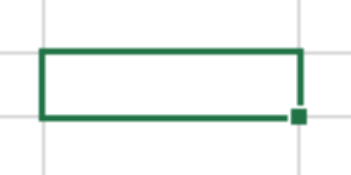

Autre solution : utiliser des boucles for

## En utilisant une boucle for

Attention ! méthode assez complexe, ne prennez pas peur !

Syntaxe :

```
for (i in 1:dim(dataframe)[1]) {
  if (dataframe$variable[i] == "cible") {
    dataframe$autre.variable [i] <- "contenu"
  } else {
    dataframe$autre.variable[i] <- "autre contenu"
  }
}
```

Avec possibilité de compléter par d'autres if, else if à volonté Avantage par rapport à Excel : quasi aucune limite !

## En utilisant une boucle for

En décrypté :

```
for (i in 1:dim(dataframe)[1]) {
  if (dataframe$variable[i] == "cible") {
    dataframe$autre.variable [i] <- "contenu"
  } else {
    dataframe$autre.variable[i] <- "autre contenu"
  }
}
```

- i : variable temporaire dans laquelle le numéro de la ligne va être stocké
- in 1:dim(dataframe) : donne la durée de la boucle, ici de la ligne 1 au nombre de lignes que comporte le dataframe
- [1] : commencer à la première ligne
- boucle if standard excepté que l'on spécifie qu'il s'agit de la valeur de la ligne numéro i

la fonction for fait tourner la boucle une première fois pour la ligne 1, puis une seconde fois pous la ligne 2, etc.

## En utilisant une boucle for

En décrypté :

```
for (i in 1:dim(dataframe)[1]) {
  if (dataframe$variable[i] == "cible") {
    dataframe$autre.variable [i] <- "contenu"
  } else {
    dataframe$autre.variable[i] <- "autre contenu"
  }
}
```

- [1] : commencer à la première ligne
- boucle if standard excepté que l'on spécifie qu'il s'agit de la valeur de la ligne numéro i

la fonction for fait tourner le if une première fois pour la ligne 1, puis une seconde fois pous la ligne 2, etc.

## Exemple de boucle for

Créons un nouveau dataframe :

```r
Fumeur <- c("oui", "oui", "non", "non")
Age <- c(45, 22, 12, 56)
Choix <- c("a", "b", "c", "d")

df_2 <- data.frame(Fumeur,Age,Choix)
head(df_2)
```

```
##   Fumeur Age Choix
## 1    oui  45     a
## 2    oui  22     b
## 3    non  12     c
## 4    non  56     d
```

## Exemple de boucle for

Créons une nouvelle variable dans laquelle je vais entrer le résultat de la boucle for:

```r
df_2$Garde <- NA
head(df_2)
```

```
##   Fumeur Age Choix Garde
## 1    oui  45     a    NA
## 2    oui  22     b    NA
## 3    non  12     c    NA
## 4    non  56     d    NA
```

## Exemple de boucle for

Et finalement la boucle for :

```r
for (i in 1:dim(df_2)[1]) {
  if (df_2$Fumeur[i] == "oui" & df_2$Age[i] > 40) {
    df_2$Garde[i] <- "gardé"
  } else {
    df_2$Garde[i] <- "rejetté"
  }
}

head(df_2)
```

```
##   Fumeur Age Choix   Garde
## 1    oui  45     a   gardé
## 2    oui  22     b rejetté
## 3    non  12     c rejetté
## 4    non  56     d rejetté
```

## A vous de jouer !

Rappel de la syntaxe :

```
for (i in 1:dim(dataframe)[1]) {
  if (dataframe$variable[i] == "cible") {
    dataframe$autre.variable [i] <- "contenu"
  } else {
    dataframe$autre.variable[i] <- "autre contenu"
  }
}
```

## Exercice 5

Remplacez les données manquantes pour que dans le dataframe df_2:

```r
df_2$ex.5 <- NA

# for (i in 1:dim(...)[1]) {
#   if (...$...[...] == "..." &/| ...$...[...] == ... ) {
#     ...$...[...] <- "..."
#   } else {
#     ...$...[...] <- "..."
#   }
# }
```

le/les participant/s non-fumeur/s de 56 ans soient inclus à votre étude. Les patients inclus auront la mention "gardé" alors que les autres la mention "rejetté"

## Correction de l'exercice 5

```r
for (i in 1:dim(df_2)[1]) {
  if (df_2$Fumeur[i] == "non" & df_2$Age[i] == 56) {
    df_2$ex.5[i] <- "gardé"
  } else {
    df_2$ex.5[i] <- "rejetté"
  }
}

head(df_2)
```

```
##   Fumeur Age Choix   Garde    ex.5
## 1    oui  45     a   gardé rejetté
## 2    oui  22     b rejetté rejetté
## 3    non  12     c rejetté rejetté
## 4    non  56     d rejetté   gardé
```

## Fin des souffrances !

- Au premier abord R parait compliqué mais donne infiniment plus de possibilités !

Par exemple :

```
for (i in 1:dim(from)[1]) {
  for (j in 1:dim(to)[1]) {
    if (to[j, col.to] == from[i,col.code.subj.from]) {
      to[j,col.to] <- from[i,col.from]
    }
  }
}
```

Code permettant de copier les informations d'une sous-base de données dans une grande base de données. Exemple d'application : savoir quel étudiant figure dans une grande liste d'étudiants

## Fin des souffrances !

- Au premier abord R parait compliqué mais donne infiniment plus de possibilités !
- Permet également avec les bons codes de supprimer les outliers à +2SD et -2SD
- Temps de codage non dépendant de la longueur de la base de données !
- Possibilités infinies !
- Pour y arriver il suffit de vous entrainer…

## Merci de votre attention !

[figure not shown]